# Assignment_missing_data

# Question 2: Calculate the correlation between the tariff and the fivop variables using “complete.obs”. Create a well-labeled and designed scatterplot of the relationship between these two variables. Discuss your results.

```r
cor(data$tariff, data$fiveop,use = "complete.obs", method = "pearson")
```

```
## [1] -0.2784601
```

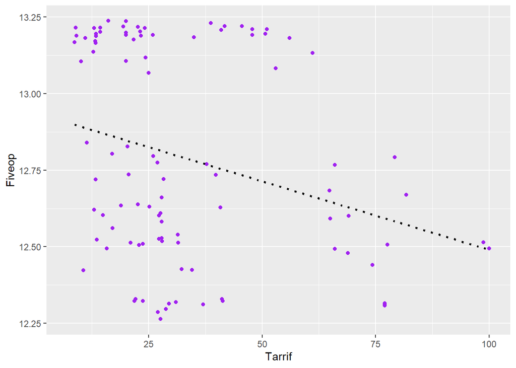

```r
p <-ggplot(data, aes(x = data$tariff, y = data$fiveop))+ geom_jitter(col = "purple")+
geom_smooth(method = "lm", se = FALSE, col = "Black", lty = 3)+

xlab("Tarrif")+
ylab("Fiveop")

p
```

The correlation is a lower negative correlation of -0.2784601. The higher the tarrif rate the lesser open the country is.

# Question 3: Are there differences between observations missing and not missing the tariff variable in terms of level of democracy, population, and gross domestic product?

```r
data$missing <- 1
data$missing[data$tariff!="NA"] <-0
data %>%
  group_by(missing) %>%
  summarize(mean_democracy= mean(polity, na.rm = TRUE))
```

```
## # A tibble: 2 x 2
##   missing mean_democracy
##     <dbl>          <dbl>
## 1       0           3.43
## 2       1           1.90
```

```r
data %>%
  group_by(missing) %>%
  summarize(mean_population= mean(pop, na.rm = TRUE))
```

```
## # A tibble: 2 x 2
##   missing mean_population
##     <dbl>           <dbl>
## 1       0      160275886.
## 2       1      129698181.
```

```r
data%>%
  group_by(missing) %>%
  summarize(mean_gdp= mean(gdp.pc, na.rm = TRUE))
```

```
## # A tibble: 2 x 2
##   missing mean_gdp
##     <dbl>    <dbl>
## 1       0    2023.
## 2       1    1565.
```

Here we realize that when there are NA values, there is a lower democracy, lower population and lower mean gdp.

# Question 4: Use the Amelia package to impute missing data for the freetrade data set. Extract one of the imputations. Recalcuate the correlation between the tariff and the fivop variables. Create a well-labeled and designed scatterplot of the relationship between these two variables. Do the results differ from the original? If so, how?

```r
amelia.data <- data %>% select(-country)
res.amelia <- amelia(amelia.data, m = 5) # m is how many imputations.
```

[output not shown]

```r
# extract one of the imputations
data_amelia <- res.amelia$imputations[[3]]

#Recalcuate the correlation between the tariff and the fivop variables.

cor(data_amelia$tariff, data_amelia$fiveop, use = "complete.obs", method = "pearson")
```

```
## [1] -0.4460877
```

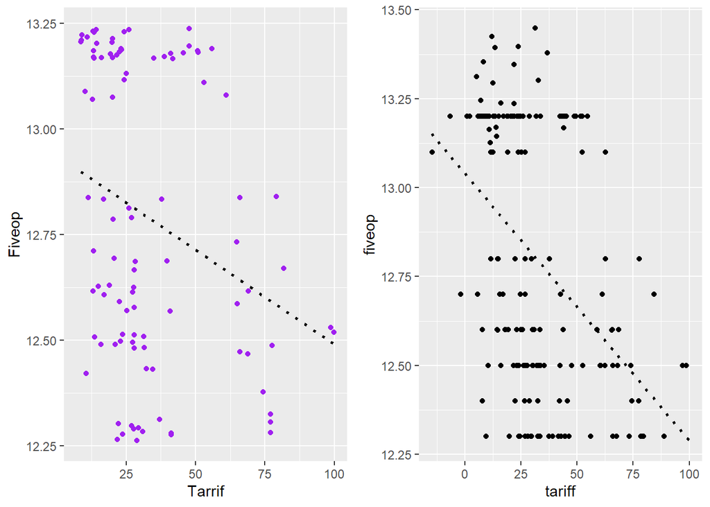

```r
p2 <- ggplot(data_amelia, aes(x = tariff, y = fiveop)) +
  geom_jitter(width = 4) +
  geom_smooth(method = "lm", se = FALSE, col = "Black", lty = 3) +
  labs(
  x = "tariff",
  y = "fiveop"

)



grid.arrange(p, p2, nrow = 1)
```

# References

Milner, Helen and Keiko Kubota. 2005. “Why the move to free trade? Democracy and trade policy in the developing countries.” International Organization. 59(1):107–143.